# 310657002_林奕勳_hw05-for-mpg-data

```r
library('tidyverse')
```

```r
library(ggplot2)
library(tidyr)
library(dplyr)
library(moments)
library(viridis)
library(caTools)
library(rpart)
library(rpart.plot)
library(glmnet)
library(caret)
square_error = function(test_data,ture_data){
  ans = sum((test_data-ture_data)**2)
  return (ans)
}
```

```r
feature_name_mpg = c('mpg','cylinders','displacement','horsepower','weight','acceleration','model year','origin','car name')
data_mpg = read.table("C:\\Users\\xx958\\OneDrive\\桌面\\nycu 碩一_上\\數據科學\\mpg\\auto-mpg.data",head=F,col.names=feature_name_mpg)
data_mpg = data_mpg[1:8]

str(data_mpg)
```

```
## 'data.frame':    398 obs. of  8 variables:
##  $ mpg         : num  18 15 18 16 17 15 14 14 14 15 ...
##  $ cylinders   : int  8 8 8 8 8 8 8 8 8 8 ...
##  $ displacement: num  307 350 318 304 302 429 454 440 455 390 ...
##  $ horsepower  : chr  "130.0" "165.0" "150.0" "150.0" ...
##  $ weight      : num  3504 3693 3436 3433 3449 ...
##  $ acceleration: num  12 11.5 11 12 10.5 10 9 8.5 10 8.5 ...
##  $ model.year  : int  70 70 70 70 70 70 70 70 70 70 ...
##  $ origin      : int  1 1 1 1 1 1 1 1 1 1 ...
```

```r
# it is show that have 398 datas and 8 variables(mpg is label orthers is feature)
dim(data_mpg)
```

```
## [1] 398   8
```

## change type of data to numerice but probuct NA

```r
for (i in names(data_mpg)){
  data_mpg[[i]]=as.numeric(data_mpg[[i]])
}
summary(data_mpg)
```

```
##       mpg          cylinders      displacement     horsepower        weight
##  Min.   : 9.00   Min.   :3.000   Min.   : 68.0   Min.   : 46.0   Min.   :1613
##  1st Qu.:17.50   1st Qu.:4.000   1st Qu.:104.2   1st Qu.: 75.0   1st Qu.:2224
##  Median :23.00   Median :4.000   Median :148.5   Median : 93.5   Median :2804
##  Mean   :23.51   Mean   :5.455   Mean   :193.4   Mean   :104.5   Mean   :2970
##  3rd Qu.:29.00   3rd Qu.:8.000   3rd Qu.:262.0   3rd Qu.:126.0   3rd Qu.:3608
##  Max.   :46.60   Max.   :8.000   Max.   :455.0   Max.   :230.0   Max.   :5140
##                                                  NA's   :6
##   acceleration     model.year        origin
##  Min.   : 8.00   Min.   :70.00   Min.   :1.000
##  1st Qu.:13.82   1st Qu.:73.00   1st Qu.:1.000
##  Median :15.50   Median :76.00   Median :1.000
##  Mean   :15.57   Mean   :76.01   Mean   :1.573
##  3rd Qu.:17.18   3rd Qu.:79.00   3rd Qu.:2.000
##  Max.   :24.80   Max.   :82.00   Max.   :3.000
##
```

## find NA , and horsepower have 6 NA Missing value

```r
colSums(is.na(data_mpg))
```

```
##          mpg    cylinders displacement   horsepower       weight acceleration
##            0            0            0            6            0            0
##   model.year       origin
##            0            0
```

```r
data_mpg[is.na(data_mpg$horsepower),]
```

```
##      mpg cylinders displacement horsepower weight acceleration model.year
## 33  25.0         4           98         NA   2046         19.0         71
## 127 21.0         6          200         NA   2875         17.0         74
## 331 40.9         4           85         NA   1835         17.3         80
## 337 23.6         4          140         NA   2905         14.3         80
## 355 34.5         4          100         NA   2320         15.8         81
## 375 23.0         4          151         NA   3035         20.5         82
##     origin
## 33       1
## 127      1
## 331      2
## 337      1
## 355      2
## 375      1
```

## and remove missing value

```r
miss_value = which(is.na(data_mpg$horsepower)==1)
data_mpg = data_mpg[-miss_value,]
```

find the displacement and weight have high association with mpg

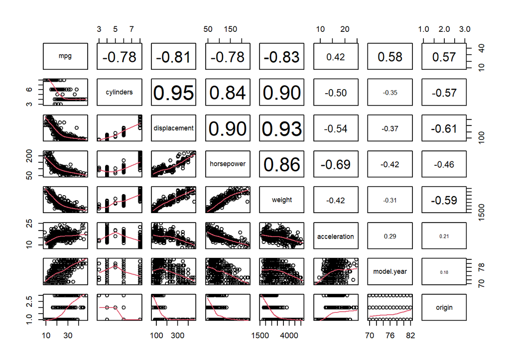

```r
panel.cor=function(x,y,digits=2,prefix="",cex.cor=10,...)
  {
  usr=par("usr")
  on.exit(par(usr))
  par(usr = c(0, 1, 0, 1))
  r=cor(x,y)
  txt=format(c(r,0.123456789),digits=digits)[1]
  txt=paste(prefix,txt,sep ="")
  if(missing(cex.cor)) cex.cor=1/strwidth(txt)
  text(0.5,0.5,txt,cex=cex.cor*abs(r))
  }
pairs(data_mpg,lower.panel=panel.smooth,upper.panel=panel.cor)
```

split training data and testing data

```r
sample = sample.split(c(1:length(data_mpg$mpg)), SplitRatio = 0.75)
train = subset(data_mpg, sample == TRUE)
test  = subset(data_mpg, sample == FALSE)
test['interaction'] = test[,'horsepower']*test['weight']
train['interaction'] = train[,'horsepower']*train['weight']
```

by coefficient we take feature (displacement,horsepower,weight) to fit regression ,and plot QQ-plot (residual is normal distribution)and find they have linear (p-value < 0.5)

```r
regression_displacement = lm(mpg~displacement,data=train)
regression_horsepower= lm(mpg~horsepower,data=train)
regression_weight = lm(mpg~weight,data=train)
summary(regression_displacement)
```

```
##
## Call:
## lm(formula = mpg ~ displacement, data = train)
##
## Residuals:
##      Min       1Q   Median       3Q      Max
## -12.5988  -3.0244  -0.3094   2.3403  16.9342
##
## Coefficients:
##               Estimate Std. Error t value Pr(>|t|)
## (Intercept)  34.680655   0.539726   64.26   <2e-16 ***
## displacement -0.058312   0.002426  -24.03   <2e-16 ***
## ---
## Signif. codes:  0 '***' 0.001 '**' 0.01 '*' 0.05 '.' 0.1 ' ' 1
##
## Residual standard error: 4.472 on 292 degrees of freedom
## Multiple R-squared:  0.6642, Adjusted R-squared:  0.663
## F-statistic: 577.5 on 1 and 292 DF,  p-value: < 2.2e-16
```

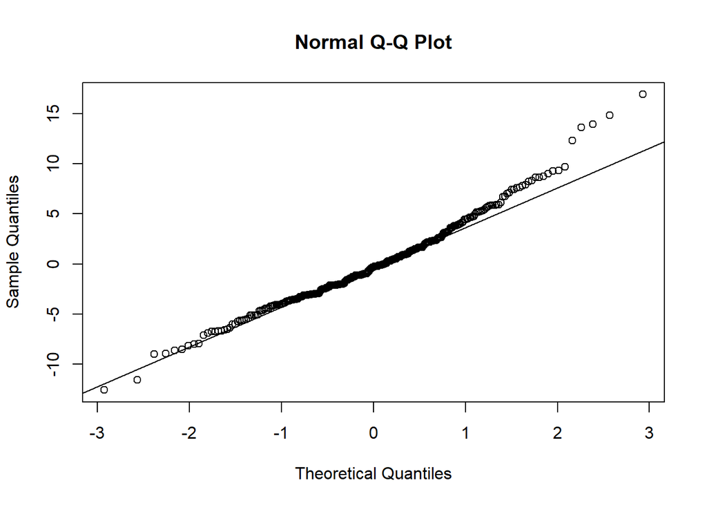

```r
qqnorm(regression_displacement$residuals)
qqline(regression_displacement$residuals)
```

```r
summary(regression_horsepower)
```

```
##
## Call:
## lm(formula = mpg ~ horsepower, data = train)
##
## Residuals:
##      Min       1Q   Median       3Q      Max
## -13.3341  -3.4648  -0.3779   2.9827  17.2190
##
## Coefficients:
##              Estimate Std. Error t value Pr(>|t|)
## (Intercept) 39.101504   0.803771   48.65   <2e-16 ***
## horsepower  -0.149547   0.007127  -20.98   <2e-16 ***
## ---
## Signif. codes:  0 '***' 0.001 '**' 0.01 '*' 0.05 '.' 0.1 ' ' 1
##
## Residual standard error: 4.873 on 292 degrees of freedom
## Multiple R-squared:  0.6013, Adjusted R-squared:  0.5999
## F-statistic: 440.3 on 1 and 292 DF,  p-value: < 2.2e-16
```

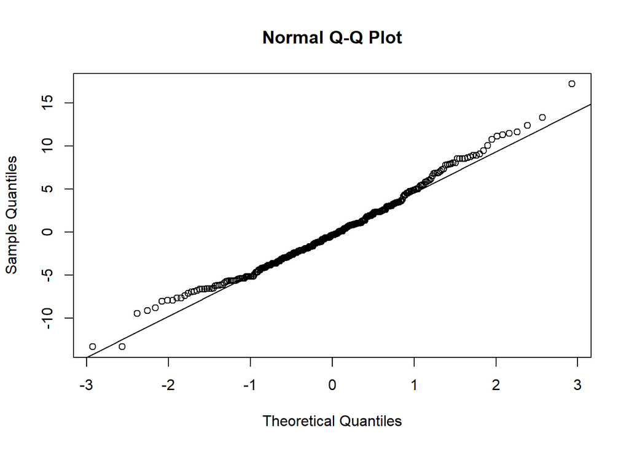

```r
qqnorm(regression_horsepower$residuals)
qqline(regression_horsepower$residuals)
```

```r
summary(regression_weight)
```

```
##
## Call:
## lm(formula = mpg ~ weight, data = train)
##
## Residuals:
##      Min       1Q   Median       3Q      Max
## -11.6617  -2.7651  -0.1229   2.3462  16.8333
##
## Coefficients:
##               Estimate Std. Error t value Pr(>|t|)
## (Intercept) 45.5921559  0.8830473   51.63   <2e-16 ***
## weight      -0.0075002  0.0002857  -26.25   <2e-16 ***
## ---
## Signif. codes:  0 '***' 0.001 '**' 0.01 '*' 0.05 '.' 0.1 ' ' 1
##
## Residual standard error: 4.21 on 292 degrees of freedom
## Multiple R-squared:  0.7024, Adjusted R-squared:  0.7014
## F-statistic: 689.1 on 1 and 292 DF,  p-value: < 2.2e-16
```

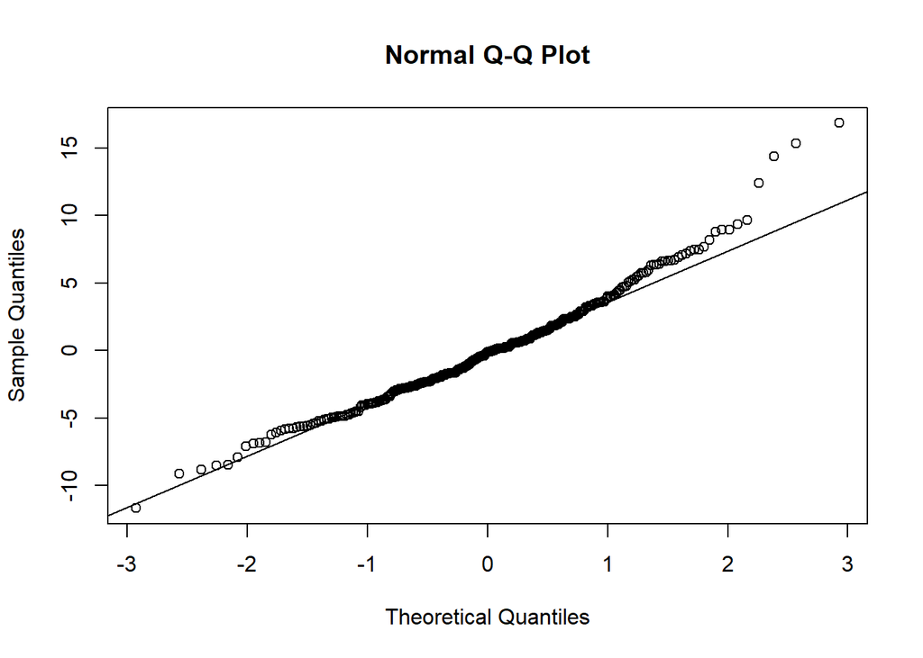

```r
qqnorm(regression_weight$residuals)
qqline(regression_weight$residuals)
```

but when we combine they find that displacement is not linear (p-value > 0.05),since it have Multi-Collinearity with horsepower

```r
regression =  lm(mpg~displacement+horsepower+weight,data=train)
summary(regression)
```

```
##
## Call:
## lm(formula = mpg ~ displacement + horsepower + weight, data = train)
##
## Residuals:
##      Min       1Q   Median       3Q      Max
## -11.3336  -2.7527  -0.4938   2.3488  16.5399
##
## Coefficients:
##                Estimate Std. Error t value Pr(>|t|)
## (Intercept)  43.7236525  1.3257174  32.981  < 2e-16 ***
## displacement -0.0097363  0.0071798  -1.356   0.1761
## horsepower   -0.0324482  0.0136481  -2.377   0.0181 *
## weight       -0.0050792  0.0007716  -6.583 2.16e-10 ***
## ---
## Signif. codes:  0 '***' 0.001 '**' 0.01 '*' 0.05 '.' 0.1 ' ' 1
##
## Residual standard error: 4.119 on 290 degrees of freedom
## Multiple R-squared:  0.717,  Adjusted R-squared:  0.7141
## F-statistic: 244.9 on 3 and 290 DF,  p-value: < 2.2e-16
```

so we remove displacement and fit regression again

```r
regression_final =  lm(mpg~horsepower+weight,data=train)
summary(regression_final)
```

```
##
## Call:
## lm(formula = mpg ~ horsepower + weight, data = train)
##
## Residuals:
##      Min       1Q   Median       3Q      Max
## -10.9017  -2.7411  -0.3752   2.3156  16.5629
##
## Coefficients:
##              Estimate Std. Error t value Pr(>|t|)
## (Intercept) 45.073277   0.877050  51.392  < 2e-16 ***
## horsepower  -0.042154   0.011638  -3.622 0.000345 ***
## weight      -0.005828   0.000540 -10.791  < 2e-16 ***
## ---
## Signif. codes:  0 '***' 0.001 '**' 0.01 '*' 0.05 '.' 0.1 ' ' 1
##
## Residual standard error: 4.125 on 291 degrees of freedom
## Multiple R-squared:  0.7152, Adjusted R-squared:  0.7133
## F-statistic: 365.4 on 2 and 291 DF,  p-value: < 2.2e-16
```

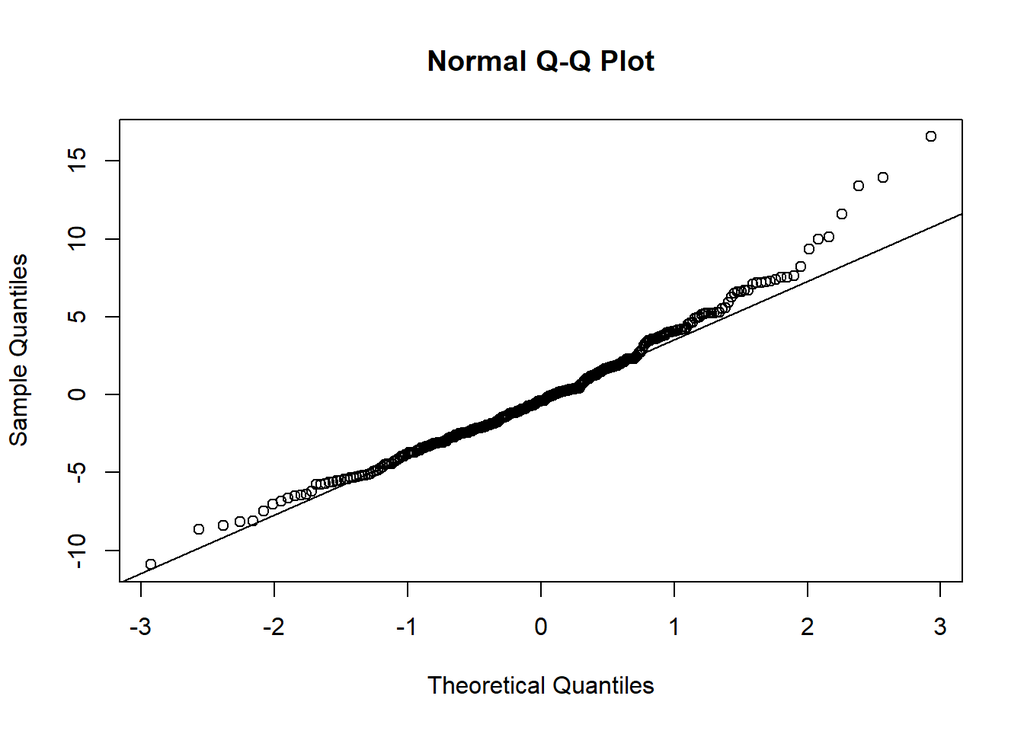

```r
qqnorm(regression_final$residuals)
qqline(regression_final$residuals)
```

```r
regression_MSE = sum(regression$residuals**2)
regression_final_MSE = sum(regression_final$residuals**2)
cat('have displacement regression of MSE : ' ,regression_MSE,'\n',
    'no displacement regression of MSE : ' ,regression_final_MSE)
```

```
## have displacement regression of MSE :  4920.765
##  no displacement regression of MSE :  4951.968
```

compare regression have displacement and no displacement adjust R square ,have same conclusion

```r
cat('have displacement regression of adjust R square : ' ,summary(regression)$adj.r.squared,'\n',
    'no displacement regression of adjust R square : ' ,summary(regression_final)$adj.r.squared)
```

```
## have displacement regression of adjust R square :  0.7140955
##  no displacement regression of adjust R square :  0.7132713
```

and I try to fit interaction regression, and find that MSE are had reduce

```r
regression_final_interaction =  lm(mpg~horsepower+weight+horsepower*weight,data=train)
cat('have interaction regression of MSE : ' ,sum(regression_final_interaction$residuals**2))
```

```
## have interaction regression of MSE :  4190.818
```

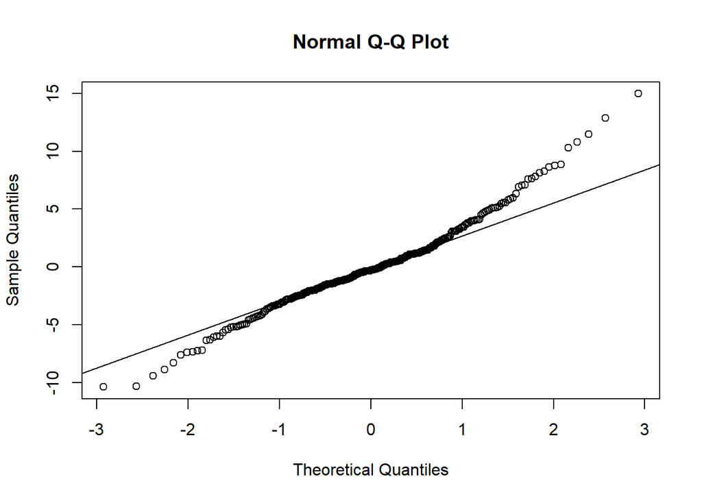

```r
qqnorm(regression_final_interaction$residuals)
qqline(regression_final_interaction$residuals)
```

Use testing data calculate square error , compare have interaction and no interaction regression

```r
predict_from_regression = predict(regression_final,test[,c('horsepower','weight')])
predict_from_interaction_regression = predict(regression_final_interaction,test[,c('horsepower','weight','interaction')])

square_error_value = square_error(predict_from_regression,test[,'mpg'])
cat(' regression square error : ',square_error_value)
```

```
##  regression square error :  2060.218
```

```r
square_error_value=square_error(predict_from_interaction_regression,test[,'mpg'])
cat('regression add interaction square error : ',square_error_value)
```

```
## regression add interaction square error :  1816.192
```

take log for mpg (label) , and fit regression add interaction term , calculate square error

```r
log_regression_interaction =  lm(log(mpg)~horsepower+weight+horsepower*weight,data=train)
predict_from_interaction_log_regression=predict(log_regression_interaction,test[,c('horsepower','weight','interaction')])
predict_from_interaction_log_regression = exp(predict_from_interaction_log_regression)
square_error_value=square_error(predict_from_interaction_log_regression,test['mpg'])
cat('log regression add interaction square error : ',square_error_value)
```

```
## log regression add interaction square error :  1903.241
```

no any process for data , and fit regression for all data

```r
regression =  lm((mpg)~.,data=train[,-c(9)])
predict_regression=predict(regression,test[,-c(1,9)])
square_error_value=square_error(predict_regression,test['mpg'])
cat(' regression square error : ',square_error_value)
```

```
##  regression square error :  1160.516
```

```r
summary(regression)
```

```
##
## Call:
## lm(formula = (mpg) ~ ., data = train[, -c(9)])
##
## Residuals:
##     Min      1Q  Median      3Q     Max
## -9.7228 -2.2901  0.1265  1.9923 13.7353
##
## Coefficients:
##                Estimate Std. Error t value Pr(>|t|)
## (Intercept)  -1.156e+01  5.229e+00  -2.210  0.02788 *
## cylinders    -9.238e-01  3.762e-01  -2.456  0.01466 *
## displacement  2.368e-02  8.507e-03   2.783  0.00574 **
## horsepower   -1.120e-02  1.475e-02  -0.759  0.44852
## weight       -6.481e-03  7.298e-04  -8.881  < 2e-16 ***
## acceleration  1.129e-01  1.124e-01   1.004  0.31614
## model.year    6.885e-01  5.793e-02  11.885  < 2e-16 ***
## origin        1.127e+00  3.158e-01   3.569  0.00042 ***
## ---
## Signif. codes:  0 '***' 0.001 '**' 0.01 '*' 0.05 '.' 0.1 ' ' 1
##
## Residual standard error: 3.32 on 286 degrees of freedom
## Multiple R-squared:  0.8187, Adjusted R-squared:  0.8143
## F-statistic: 184.5 on 7 and 286 DF,  p-value: < 2.2e-16
```

# final linear regression and cross-validation

```r
train.control <- trainControl(method = "cv", number = 10)
# Train the model
model <- train((mpg)~horsepower+weight+model.year+origin+interaction, data = train, method = "lm",
               trControl = train.control)
# Summarize the results
print(model)
```

```
## Linear Regression
##
## 294 samples
##   5 predictor
##
## No pre-processing
## Resampling: Cross-Validated (10 fold)
## Summary of sample sizes: 264, 264, 265, 263, 265, 265, ...
## Resampling results:
##
##   RMSE      Rsquared   MAE
##   2.869045  0.8711447  2.20729
##
## Tuning parameter 'intercept' was held constant at a value of TRUE
```

```r
predict_model=predict(model,test[,c('horsepower','weight','model.year','origin','interaction')])
square_error_value=square_error(predict_model,test['mpg'])
cat(' regression square error : ',square_error_value)
```

```
##  regression square error :  911.5768
```

## Regression Trees

```r
regTree = rpart((mpg)~horsepower+weight,data=train,method = "anova")
regTree
```

```
## n= 294
##
## node), split, n, deviance, yval
##       * denotes terminal node
##
##  1) root 294 17389.2700 23.32483
##    2) weight>=2803.5 145  2561.8110 17.33517
##      4) horsepower>=139.5 64   292.1994 14.09688 *
##      5) horsepower< 139.5 81  1068.1870 19.89383
##       10) weight>=3273.5 36   265.6297 18.19722 *
##       11) weight< 3273.5 45   616.0324 21.25111 *
##    3) weight< 2803.5 149  4563.0700 29.15369
##      6) horsepower>=74.5 90  1687.9560 26.64000
##       12) horsepower>=88.5 40   677.8160 24.91000 *
##       13) horsepower< 88.5 50   794.6512 28.02400 *
##      7) horsepower< 74.5 59  1438.9620 32.98814 *
```

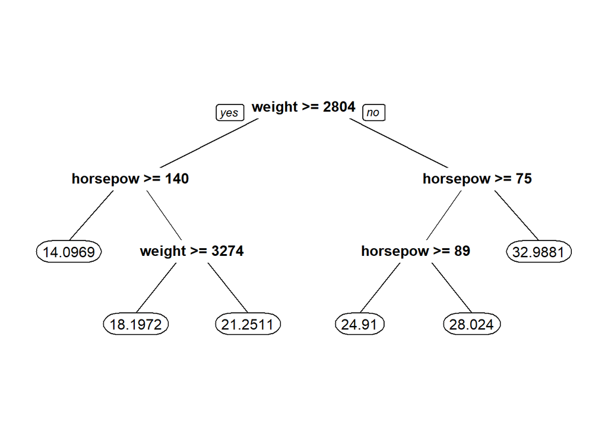

```r
prp(regTree, digits=6)
```

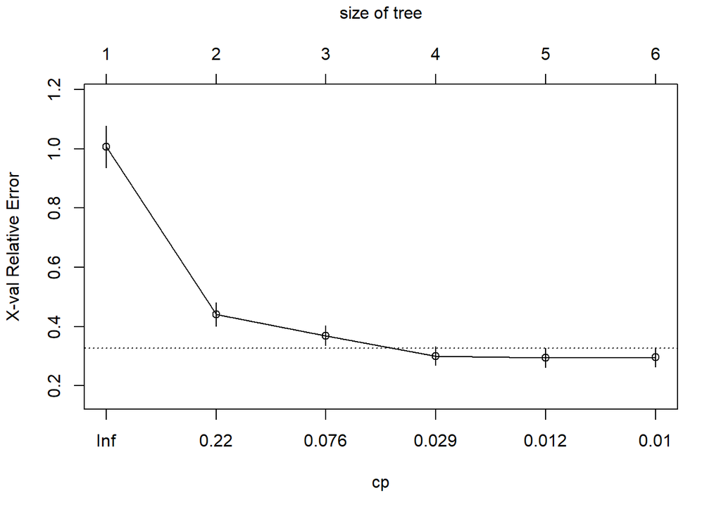

```r
plotcp(regTree)
```

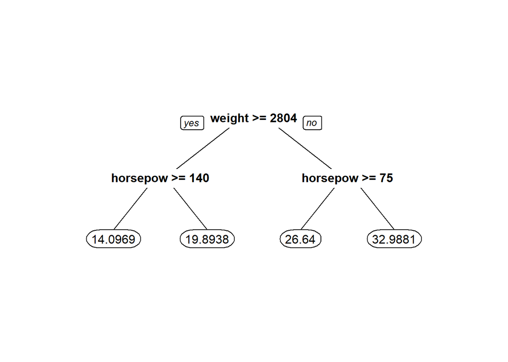

```r
regTree_pruned = prune(regTree, cp=0.034)
prp(regTree_pruned, digits=6)
```

```r
predict_regression_tree=predict(regTree_pruned,test[,c('horsepower','weight')])
square_error_value=square_error(predict_regression_tree,test[,'mpg'])
cat('regression tree square error : ',square_error_value)
```

```
## regression tree square error :  2545.846
```